# Monte Carlo Simulation

Lecture 10

March 4, 2024

# Previously In Class

## Probability Models

- Probability Models for Data-Generating Processes
- Can be used for statistical models and simulation models (discrepancy)

## What’s Next?

- How do we:
  - Simulate from models/propagate uncertainty;
  - Go beyond MLE/MAP estimation for parameter values?
- Model assessment/selection

# Monte Carlo Simulation

## Stochastic Simulation

**Goal**: Estimate $\mathbb{E}_p\left[f(x)\right]$, $x \sim p(x)$

- Standard approach: Compute $\mathbb{E}_p\left[f(x)\right] = \int_X f(x)p(x)dx$
- Monte Carlo:
  - Sample $x^1, x^2, \ldots, x^N \sim p(x)$
  - Estimate $\mathbb{E}_p\left[f(x)\right] \approx \sum_{n=1}^N f(x^n)$ / N

## Monte Carlo Process Schematic

[figure not shown]

## Goals of Monte Carlo

Monte Carlo is a broad method, which can be used to:

1. Obtain probability distributions of outputs;
2. Estimate deterministic quantities (*Monte Carlo estimation*).

## MC Example: Finding $\pi$

How can we use MC to estimate $\pi$?

**Hint**: Think of $\pi$ as an expected value…

## MC Example: Finding $\pi$

Finding $\pi$ by sampling random values from the unit square and computing the fraction in the unit circle. This is an example of **Monte Carlo integration**.

$$\frac{\text{Area of Circle}}{\text{Area of Square}} = \frac{\pi}{4}$$

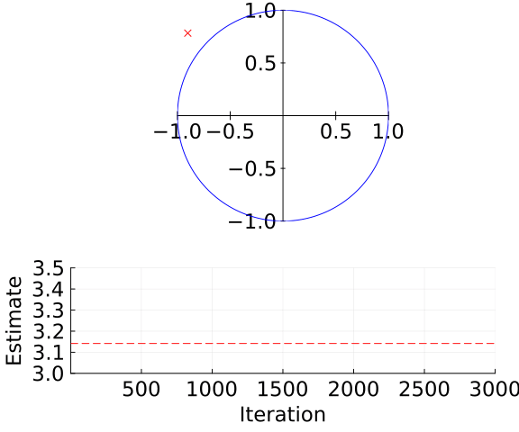

Figure 1: MCMC Estimation of pi

```julia
function circleShape(r)
    θ = LinRange(0, 2 * π, 500)
    r * sin.(θ), r * cos.(θ)
end

nsamp = 3000
unif = Uniform(-1, 1)
x = rand(unif, (nsamp, 2))
l = mapslices(v -> sum(v.^2), x, dims=2)
in_circ = l .< 1
pi_est = [4 * mean(in_circ[1:i]) for i in 1:nsamp]

plt1 = plot(
    1,
    xlim = (-1, 1),
    ylim = (-1, 1),
    legend = false,
    markersize = 4,
    framestyle = :origin,
    tickfontsize=16,
    grid=:false
    )
plt2 = plot(
    1,
    xlim = (1, nsamp),
    ylim = (3, 3.5),
    legend = :false,
    linewidth=3,
    color=:black,
    tickfontsize=16,
    guidefontsize=16,
    xlabel="Iteration",
    ylabel="Estimate",
    right_margin=5mm
)
hline!(plt2, [π], color=:red, linestyle=:dash)
plt = plot(plt1, plt2, layout=Plots.grid(2, 1, heights=[2/3, 1/3]), size=(600, 500))

plot!(plt, circleShape(1), linecolor=:blue, lw=1, aspectratio=1, subplot=1)


mc_anim = @animate for i = 1:nsamp
    if l[i] < 1
        scatter!(plt[1], Tuple(x[i, :]), color=:blue, markershape=:x, subplot=1)
    else
        scatter!(plt[1], Tuple(x[i, :]), color=:red, markershape=:x, subplot=1)
    end
    push!(plt, 2, i, pi_est[i])
end every 100

gif(mc_anim, "figures/mc_pi.gif", fps=3)
```

## MC Example: Dice

What is the probability of rolling 4 dice for a total of 19?

Can simulate dice rolls and find the frequency of 19s among the samples.

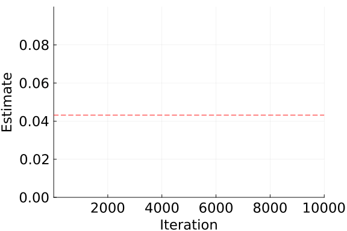

```julia
function dice_roll_repeated(n_trials, n_dice)
    dice_dist = DiscreteUniform(1, 6)
    roll_results = zeros(n_trials)
    for i=1:n_trials
        roll_results[i] = sum(rand(dice_dist, n_dice))
    end
    return roll_results
end

nsamp = 10000
# roll four dice 10000 times
rolls = dice_roll_repeated(nsamp, 4)

# calculate probability of 19
sum(rolls .== 19) / length(rolls)

# initialize storage for frequencies by sample length
avg_freq = zeros(length(rolls))
std_freq = zeros(length(rolls))

# compute average frequencies of 19
avg_freq[1] = (rolls[1] == 19)
count = 1
for i=2:length(rolls)
    avg_freq[i] = (avg_freq[i-1] * (i-1) + (rolls[i] == 19)) / i
    std_freq[i] = 1/sqrt(i-1) * std(rolls[1:i] .== 19)
end

plt = plot(
    1,
    xlim = (1, nsamp),
    ylim = (0, 0.1),
    legend = :false,
    tickfontsize=16,
    guidefontsize=16,
    xlabel="Iteration",
    ylabel="Estimate",
    right_margin=8mm,
    color=:black,
    linewidth=3,
    size=(600, 400)
)
hline!(plt, [0.0432], color="red",
    linestyle=:dash)

mc_anim = @animate for i = 1:nsamp
    push!(plt, 1, i, avg_freq[i])
end every 100

gif(mc_anim, "figures/mc_dice.gif", fps=10)
```

## Monte Carlo and Uncertainty Propagation

**Monte Carlo simulation**: propagate uncertainties from inputs through a model to outputs.

This is an example of **uncertainty propagation**: draw samples from some distribution, and run them through one or more models to find the (conditional) probability of outcomes of interest (for good or bad).

## Uncertainty Propagation Flowchart

**For example**: What is the probability that a levee will be overtopped given climate and extreme sea-level uncertainty?

[figure not shown]

## What Do We Need For MC?

1. Simulation Model (Numerical/Statistical)
2. *Input Distributions*

## On Random Number Generators

Random number generators are not *really* random, only **pseudorandom**.

This is why setting a seed is important. But even that can go wrong…

[figure not shown]

XKCD Cartoon 221: Random Number

Source: [XKCD #221](https://xkcd.com/221/)

# Why Monte Carlo Works

## Monte Carlo: Formal Approach

**Formally**: Monte Carlo estimation as the computation of the expected value of a random quantity $Y$, $\mu = \mathbb{E}[Y]$.

To do this, generate $n$ independent and identically distributed values $Y_1, \ldots, Y_n$. Then the sample estimate is

$$\tilde{\mu}_n = \frac{1}{n}\sum_{i=1}^n Y_i$$

## The Law of Large Numbers

If

1. $Y$ is a random variable and its expectation exists and
2. $Y_1, \ldots, Y_n$ are independently and identically distributed

Then by the **weak law of large numbers**:

$$\lim_{n \to \infty} \mathbb{P}\left(\left|\tilde{\mu}_n - \mu\right| \leq \varepsilon \right) = 1$$

## The Law of Large Numbers

In other words, *eventually* Monte Carlo estimates will get within an arbitrary error of the true expectation.

But how large is large enough?

## Monte Carlo Sample Mean

The sample mean $\tilde{\mu}_n = \frac{1}{n}\sum_{i=1}^n Y_i$ is itself a random variable.

With some assumptions (the mean of $Y$ exists and $Y$ has finite variance), the expected Monte Carlo sample mean $\mathbb{E}[\tilde{\mu}_n]$ is

$$\frac{1}{n}\sum_{i=1}^n \mathbb{E}[Y_i] = \frac{1}{n} n \mu = \mu$$

## Monte Carlo Error

We’d like to know more about the error of this estimate for a given sample size. The variance of this estimator is

$$\tilde{\sigma}_n^2 = \text{Var}\left(\tilde{\mu}_n\right) = \mathbb{E}\left((\tilde{\mu}_n - \mu)^2\right) = \frac{\sigma_Y^2}{n}$$

So as $n$ increases, the *standard error* decreases:

$$\tilde{\sigma}_n = \frac{\sigma_Y}{\sqrt{n}}$$

## Monte Carlo Error

In other words, if we want to decrease the Monte Carlo error by 10x, we need 100x additional samples. **This is not an ideal method for high levels of accuracy.**

> Monte Carlo is an extremely bad method. It should only be used when all alternative methods are worse.

— Sokal, *Monte Carlo Methods in Statistical Mechanics*, 1996

But…often most alternatives *are* worse!

## When Might We Want to Use Monte Carlo?

If you can compute your answers analytically or through quadrature, you probably should.

But for *many* “real” problems, this is either

1. Not possible (or computationally intractable);
2. Requires a lot of stylization and simplification.

## Monte Carlo Confidence Intervals

**Basic Idea**: The *Central Limit Theorem* says that with enough samples, the errors are normally distributed:

$$\left\|\tilde{\mu}_n - \mu\right\| \to \mathcal{N}\left(0, \frac{\sigma_Y^2}{n}\right)$$

## Monte Carlo Confidence Intervals

The $\alpha$-confidence interval is:
$$\tilde{\mu}_n \pm \Phi^{-1}\left(1 - \frac{\alpha}{2}\right) \frac{\sigma_Y}{\sqrt{n}}$$

For example, the 95% confidence interval is
$$\tilde{\mu}_n \pm 1.96 \frac{\sigma_Y}{\sqrt{n}}.$$

## Sidebar: Estimating $\sigma_Y$

We don’t know the standard deviation $\sigma_Y$.

## Implications of Monte Carlo Error

Converging at a rate of $1/\sqrt{n}$ is not great. But:

- All models are wrong, and so there always exists some irreducible model error.
- We often need a lot of simulations. Do we have enough computational power?

# Key Points and Upcoming Schedule

## Key Points

- Monte Carlo: estimate by simulating summary statistics
- Instead of computing integrals, approximate through sample summaries
- MC estimates are themselves random quantities
- Confidence intervals obtained through Central Limit Theorem
- $\tilde{\mu}_n \to \mu$ at rate $1/\sqrt{n}$: not great!

## Next Classes

**Wednesday**: Monte Carlo Examples: Flood Risk and Climate Change

**Next Week**: The Bootstrap

## Assessments

**Exercise 7**: Assigned, due Friday

**Reading**: Kale et al. (2021)

# References

## References

Kale, A., Kay, M., & Hullman, J. (2021). Visual reasoning strategies for effect size judgments and decisions. *IEEE Trans. Vis. Comput. Graph.*, *27*, 272–282. https://doi.org/10.1109/TVCG.2020.3030335